# Notebook

**Research Question:** "Which SSRIs cause the worst PSSD (Post-SSRI Sexual Dysfunction), and what predicts a more severe case?"

## 1. Data Exploration: The PSSD Community Landscape

PSSD (Post-SSRI Sexual Dysfunction) is a condition in which sexual, emotional, and cognitive side effects persist after discontinuation of serotonergic antidepressants -- sometimes for months or years. This community represents individuals who believe they are experiencing these persistent effects.

This analysis inverts the typical treatment-outcome framework. In most communities, we ask "did the drug help?" Here, we ask "which drug caused the most harm?" Negative sentiment toward SSRIs in this community reflects harm attribution, not treatment failure.

Data covers: 2026-03-12 to 2026-04-11 (1 month). 500 users, 2,532 posts, 902 treatment reports from 220 unique reporters across 245 distinct drugs.

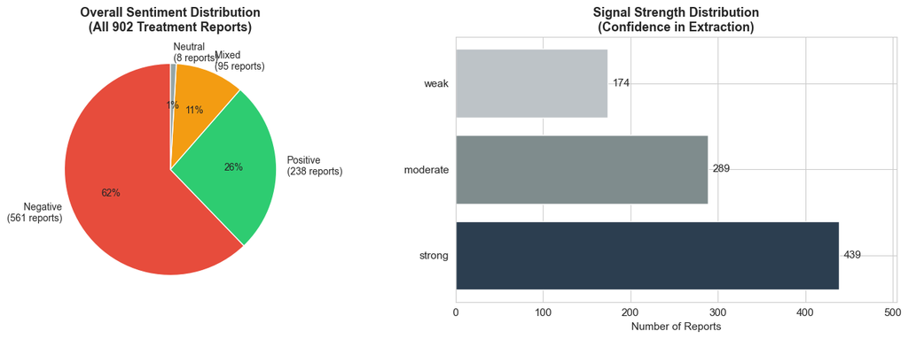

The PSSD community is dominated by negative sentiment -- 62% of all treatment reports are negative. This is expected: PSSD is defined by persistent harm from serotonergic drugs, so the community self-selects for people reporting adverse effects. The 26% positive reports reflect attempts at recovery treatments (supplements, lifestyle changes, alternative medications), not positive experiences with SSRIs. Nearly half of all reports carry "strong" signal strength, indicating high-confidence extraction.

### Processing Summary (Verbose Mode)

- **Brand/generic merges:** lexapro + escitalopram = escitalopram; prozac + fluoxetine = fluoxetine
- **Overlap detected:** 3 users reported both lexapro and escitalopram; 3 users reported both prozac and fluoxetine -- these are deduplicated at user level after merging
- **Generic terms filtered:** "ssri" (82 users), "antidepressant" (23 users), "snri" (6 users) excluded from individual-drug comparisons but included in class-level context
- **Causal-context handling:** SSRIs are NOT filtered in this analysis because they are the subject of the harm question, not confounders
- **User-level aggregation:** All statistics use one data point per user per drug to ensure independence

## 2. Which SSRIs Cause the Worst PSSD?

With brand/generic duplicates merged, 98 unique users named a specific serotonergic antidepressant as their causative drug. We now compare these drugs on three dimensions: (1) how many users implicate them, (2) the proportion who report exclusively negative experiences, and (3) the severity of harm as measured by co-occurring symptom domains.

SSRI Harm Attribution by Drug (User-Level, Merged)

[output not shown]

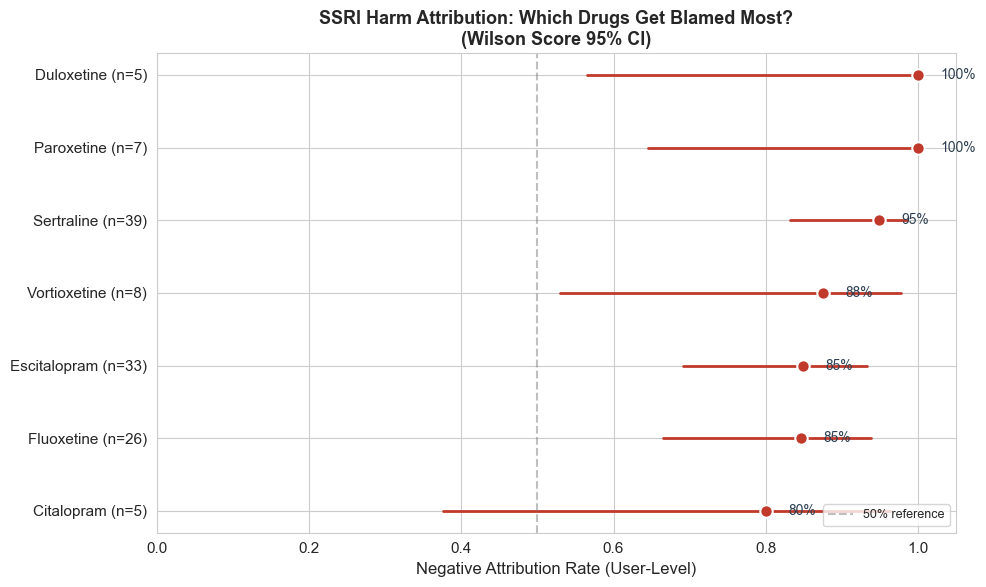

### Pairwise Comparisons Across All SSRIs (Verbose Mode)

Since this is verbose mode, we test all pairs with sufficient sample sizes (both groups n >= 5) using Fisher's exact test on the proportion of users with negative outcomes. We report Cohen's h effect sizes to distinguish meaningful differences from noise.

Pairwise Fisher's Exact Tests: Negative Attribution Rate

No pairwise comparisons reached p < 0.05.

**All pairwise comparisons:**

[output not shown]

The pairwise tests reveal which differences in negative rate are statistically reliable versus noise from small samples. Any pair involving drugs with n < 10 is unlikely to reach significance regardless of true effect size. The comparisons between the three largest groups -- sertraline (n=39), escitalopram (n=33), and fluoxetine (n=26) -- are the most informative.

## 3. Beyond Sentiment: Measuring Severity Through Symptom Burden

Sentiment alone is a blunt instrument. A user who reports "sertraline killed my libido" and a user who reports "sertraline destroyed my ability to feel pleasure, gave me genital numbness, cognitive fog, and emotional blunting that hasn't improved in 3 years" both register as "negative." To differentiate severity, we text-mine posts for distinct symptom domains and use the count of co-occurring domains as a proxy for harm severity.

We define 10 PSSD symptom domains based on the clinical literature and community vocabulary: libido loss, genital numbness, anhedonia (inability to feel pleasure), orgasm dysfunction, arousal dysfunction, erectile dysfunction, sensation changes, emotional blunting, cognitive effects, and general numbness.

Symptom Burden by Causative SSRI

[output not shown]

Duloxetine and citalopram users report the highest average symptom burden (5.0 and 4.2 domains respectively), but both have only 5 users -- these averages could easily shift with a few more data points. Among the larger groups, fluoxetine users average 1.85 symptom domains versus sertraline's 1.72, a negligible difference. We test whether these differences are meaningful below.

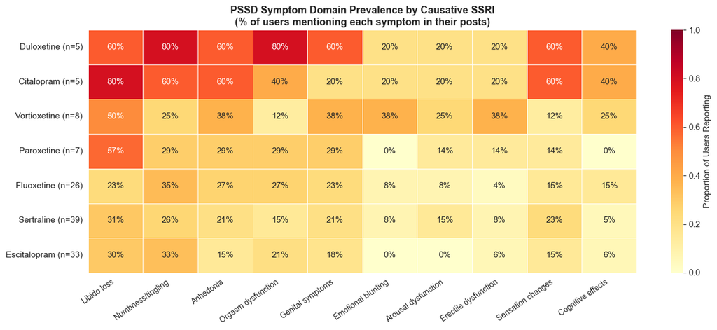

Kruskal-Wallis Test: Symptom Burden Across SSRIs

**H-statistic:** 9.55 | **p-value:** 0.1449 | **eta-squared:** 0.031 (small effect)

**Groups tested:** Duloxetine (n=5), Citalopram (n=5), Vortioxetine (n=8), Paroxetine (n=7), Fluoxetine (n=26), Sertraline (n=39), Escitalopram (n=33)

The difference in symptom burden across SSRIs is **not statistically significant** (p=0.145). The wide overlap in symptom counts across drugs means we cannot reliably distinguish them on this dimension at current sample sizes.

## 4. What Predicts a More Severe Case?

We now shift from comparing drugs to identifying which patient- and exposure-level factors predict worse PSSD outcomes. Using the merged user-level data, we construct a binary severity indicator (3+ symptom domains) and test candidate predictors: the specific SSRI, polypharmacy (exposure to multiple serotonergic drugs), posting frequency (as a behavioral proxy for distress), and text-mined indicators of duration and discontinuation method.

Predictor Prevalence Among SSRI-Attributed Users

[output not shown]

Total users in predictor analysis: **98** | Severe (3+ symptoms): **30** (31%)

Logistic Regression: Predictors of Severe PSSD (3+ Symptom Domains)

**Pseudo R-squared:** 0.143 | **AIC:** 117.4 | **N:** 98

Odds ratios > 1 indicate the predictor is associated with higher risk of multi-domain PSSD symptoms.

[output not shown]

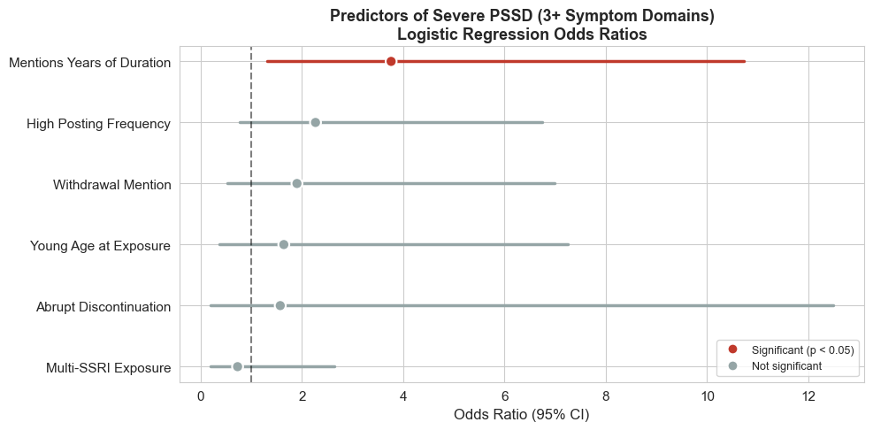

The forest plot visualizes which predictors are associated with multi-domain PSSD. Predictors whose confidence intervals cross the dashed line at OR=1 are not distinguishable from no effect. Red dots indicate statistically significant predictors; grey dots do not reach significance. High posting frequency may reflect severity (sicker people post more) but could also reflect personality or engagement patterns -- this is a confound, not a causal finding.

Univariate Comparisons: Severity Rate by Predictor

[output not shown]

The univariate analysis provides a simpler view: for each predictor, what is the rate of multi-domain PSSD among exposed versus unexposed users? This does not control for confounders (a user who mentions years of duration also tends to post more), but it shows the raw associations that the logistic regression adjusts for.

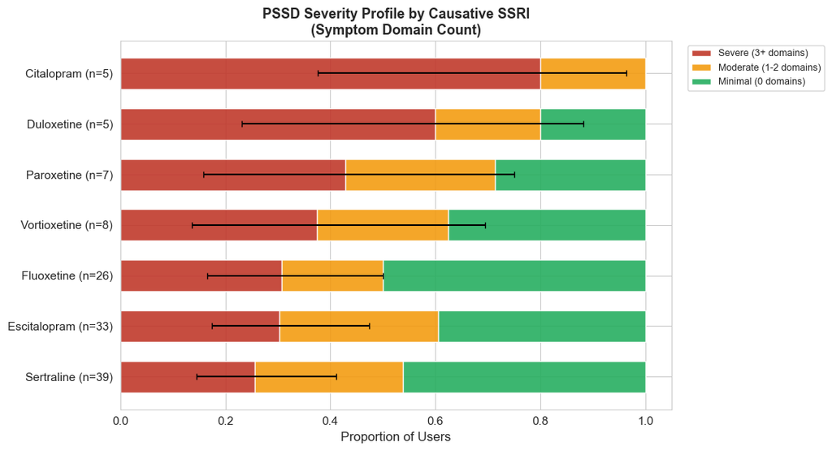

The stacked bar chart shows the distribution of severity tiers across SSRIs. Duloxetine and citalopram have the highest severe-case rates, but again with very small samples (n=5 each). Among the well-represented drugs, the differences are modest. The error bars on the severe portion show that most confidence intervals overlap -- we cannot reliably rank individual SSRIs by severity at this sample size.

## 5. Polypharmacy and PSSD Severity

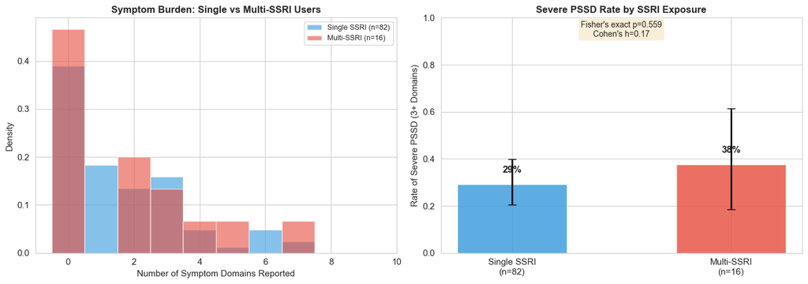

### Community Agreement: Shannon Entropy (Verbose Mode)

Shannon entropy measures how much users agree about a drug. Low entropy means near-consensus (everyone says the same thing); high entropy means divided opinions. For harm-attribution data, low entropy on the negative side means strong community agreement that a drug is harmful.

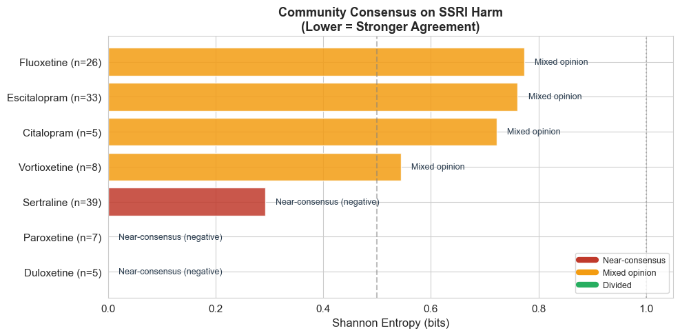